title: “World Happiness Report from year 2005-2021” output: html_document

# World Happiness Report from year 2005-2021

Kristen Blessman-Garcia

05/08/2023

## Introduction

The data is a CSV from Kaggle based on the Gallup World Poll/World Happiness Reports from 2005-2021. It shows the national average response to a question of subjective well being.

- A link to the data [World Happiness Report 2005-2021](https://www.kaggle.com/datasets/jahaidulislam/world-happiness-report-2005-2021)

### Problem Statement and Questions

- To understand global happiness trends and the factors contributing to well-being.
  - Which countries had the highest average happiness score?
  - Which countries had the lowest average happiness score?
  - How do the continents compare on their happiness score?
  - Which factors are related to an increased score on the happiness report?
- Background/Why?
  - I have practiced as an occupational therapy assistant for the past ten years and have an interest in the social/emotional well being of my clients. Also, my domain focus for data science is psychology so I wanted a relevant dataset.

## World Happiness Report is measured in Life.Ladder

Please imagine a ladder, with steps numbered from 10 at the top to 0 at the bottom.

### Ten

- The top of the ladder represents the best possible life for you.
- The bottom of the ladder represents the worst possible life for you.

## What Libraries did you use?

- library(tidyverse) #Use to tidy and filter the data with dplyr
- library(ggplot2) #Use to draw plots
- library(countrycode) #Use to categorize countries by continent

## Let’s take a look at the unfiltered data

```r
glimpse(data1)
```

```
## Rows: 2,089
## Columns: 12
## $ Country.Name                      <chr> "Afghanistan", "Afghanistan", "Afgha…
## $ Year                              <int> 2008, 2009, 2010, 2011, 2012, 2013, …
## $ Life.Ladder                       <dbl> 3.723590, 4.401778, 4.758381, 3.8317…
## $ Log.GDP.per.capita                <dbl> 7.302574, 7.472446, 7.579183, 7.5520…
## $ Social.support                    <dbl> 0.4506623, 0.5523084, 0.5390752, 0.5…
## $ Healthy.life.expectancy.at.birth  <dbl> 50.500, 50.800, 51.100, 51.400, 51.7…
## $ Freedom.to.make.life.choices      <dbl> 0.7181143, 0.6788964, 0.6001272, 0.4…
## $ Generosity                        <dbl> 0.173169285, 0.195469126, 0.12585946…
## $ Perceptions.of.corruption         <dbl> 0.8816863, 0.8500354, 0.7067661, 0.7…
## $ Positive.affect                   <dbl> 0.4142970, 0.4814214, 0.5169067, 0.4…
## $ Negative.affect                   <dbl> 0.2581955, 0.2370924, 0.2753238, 0.2…
## $ Confidence.in.national.government <dbl> 0.6120721, 0.6115452, 0.2993574, 0.3…
```

## Data Key Terms and Column names (Variables):

- GDP per capita- (variable name gdp) Gross Domestic Product
- Healthy life expectancies at birth are based on the data extracted from the World Health Organization’s (WHO) Global Health Observatory data repository

Binary Responses: Respondents answered 1 for yes and 0 for no. The number represented in the dataset is the national average of the binary responses for that year.

- Perception of corruption- “Is corruption widespread within businesses/ government or not?”
- Confidence in the national government- “Do you have confidence in your national government?”
- Social support- “If you were in trouble, do you have relatives or friends you can count on to help you?”
- Freedom to make life choices- “Are you satisfied with your freedom to choose what you do with your life?”

## Missing Data

- Compared to the large dataset of 2089 rows, the amount of missing values were negligible.

```r
#use a function to look at the number of missing values per column
sapply(data1, function(x) sum(is.na(x)))
```

```
##                      Country.Name                              Year
##                                 0                                 0
##                       Life.Ladder                Log.GDP.per.capita
##                                 0                                27
##                    Social.support  Healthy.life.expectancy.at.birth
##                                13                                58
##      Freedom.to.make.life.choices                        Generosity
##                                32                                80
##         Perceptions.of.corruption                   Positive.affect
##                               113                                24
##                   Negative.affect Confidence.in.national.government
##                                16                               216
```

- The highest missing values were for confidence in national government and perceptions of corruption which could be related to people feeling uncomfortable expressing political views in a survey.
- The dataframe has a large amount of information but we do not need all of it. So I will create a new dataframe to isolate the columns that I will be interested in.
- Create a new dataframe with only the columns of interest.

```r
data1 = data1 %>%
  #select columns of interest
  select(Country.Name, Life.Ladder, Year, Log.GDP.per.capita,
         Social.support,Freedom.to.make.life.choices,
         Healthy.life.expectancy.at.birth, Perceptions.of.corruption,
         Confidence.in.national.government)
```

- Now, let’s take a look at the average happiness score for each country over the years 2005-2021. We will find the mean of Life.Ladder for the number of years that the country participated in the survey.

```r
# Create an overview of the data
summary= data1 %>% select(Country.Name, Year, Life.Ladder) %>%
  arrange(desc(Country.Name)) %>%
# group the data by country
  group_by(Country.Name) %>%
#Find the mean and median Life.Ladder
  summarise(avg_ladder = mean(Life.Ladder),
          median_ladder = median(Life.Ladder)) %>%
  arrange(avg_ladder)
```

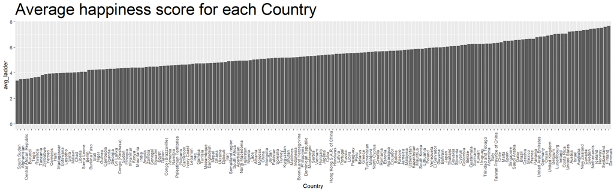

- As you can see from the last plot there are over 100 countries in the dataset. The x-axis is difficult to read because of the large number of countries. Let’s filter the data further to look at the ten highest averages of Life.Ladder.

## Highest Average scores

```r
#Find top ten average using summary and average variable
max_avg = summary %>% slice_max(avg_ladder, n = 10)
max_avg
```

```
## # A tibble: 10 × 3
##    Country.Name avg_ladder median_ladder
##    <chr>             <dbl>         <dbl>
##  1 Denmark            7.68          7.67
##  2 Finland            7.61          7.67
##  3 Switzerland        7.53          7.51
##  4 Norway             7.50          7.44
##  5 Iceland            7.46          7.51
##  6 Netherlands        7.46          7.46
##  7 Sweden             7.37          7.38
##  8 Canada             7.35          7.42
##  9 New Zealand        7.30          7.28
## 10 Australia          7.27          7.26
```

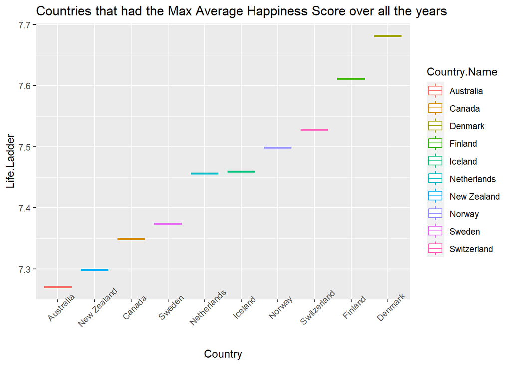

-Finland and Denmark had the highest average happiness scores over the timeframe 2005-2021.

## Now Let’s Filter the data and find the ten countries with the lowest average happiness score

```
## # A tibble: 10 × 3
##    Country.Name             avg_ladder median_ladder
##    <chr>                         <dbl>         <dbl>
##  1 South Sudan                    3.40          3.36
##  2 Afghanistan                    3.51          3.72
##  3 Central African Republic       3.51          3.57
##  4 Burundi                        3.55          3.71
##  5 Togo                           3.60          3.82
##  6 Rwanda                         3.65          3.52
##  7 Tanzania                       3.70          3.67
##  8 Zimbabwe                       3.84          3.72
##  9 Yemen                          3.91          4.01
## 10 Comoros                        3.94          3.90
```

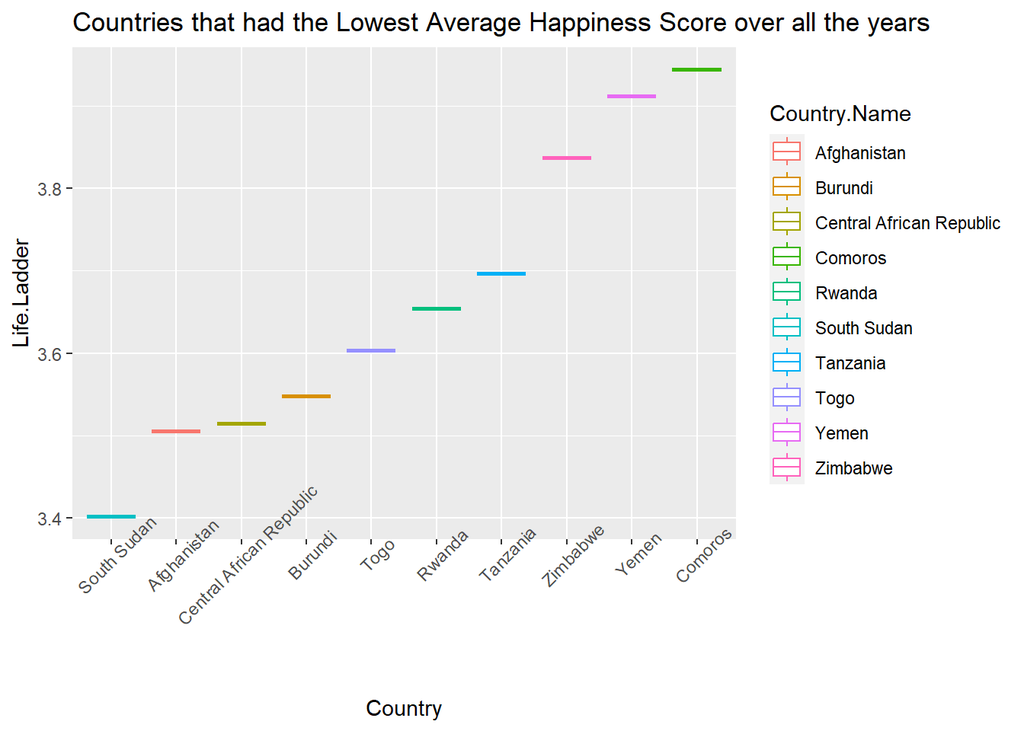

```r
#use slice_min to find the ten lowest averages and then plot
min_avg = summary %>% slice_min(avg_ladder, n = 10)
min_avg
```

- South Sudan and Afghanistan had the lowest average scores over the time frame in the dataset.

## The countries with the highest happiness scores most frequently

- Rather than taking an average, let’s take a look at the max_slice for happiness scores. Let’s see how often in the time span from 2005-2021 the countries had a max score.

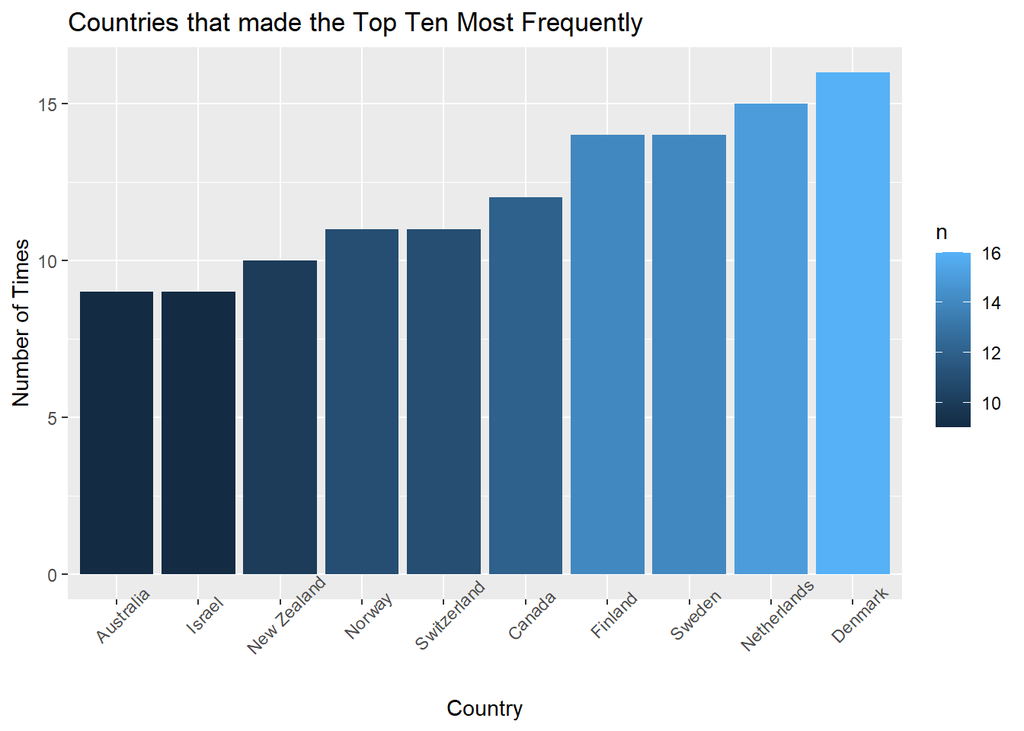

- It looks like the country of Denmark which had the highest average happiness score, also made the top ten consistently.
- Since we looked at the max_slice, let’s also take a look at the slice_min. -This will show us the lowest recorded scores and we can look for extreme values.

```
##                Country.Name Year Life.Ladder
## 1                   Lebanon 2021    2.178809
## 2               Afghanistan 2019    2.375092
## 3               Afghanistan 2021    2.436034
## 4                   Lebanon 2020    2.633753
## 5               Afghanistan 2017    2.661718
## 6                     Syria 2013    2.687553
## 7  Central African Republic 2016    2.693061
## 8                  Zimbabwe 2019    2.693523
## 9               Afghanistan 2018    2.694303
## 10                  Liberia 2015    2.701591
## 11                     Togo 2008    2.807855
## 12              South Sudan 2017    2.816622
## 13                     Togo 2014    2.838959
## 14              South Sudan 2016    2.888112
## 15                 Tanzania 2016    2.902734
## 16                  Burundi 2014    2.904535
```

- We can see some differences between the min_slice and the average low dataframe. This could be from extreme values or that a country had an out of the ordinary low happiness score.
- I noticed that Lebanon is in the min_slice for the years of 2020 and 2021, yet it’s average over all of the years is not in the bottom ten. This could be related to the pandemic, however it’s difficult to know for sure since the dataset ends in 2021 and the pandemic was ongoing.

## The countries with the lowest happiness scores most frequently

- This plot is not looking at averages, it is counting the lowest happiness scores. Some of these are extreme values for one year that do not represent the national average for all the years.

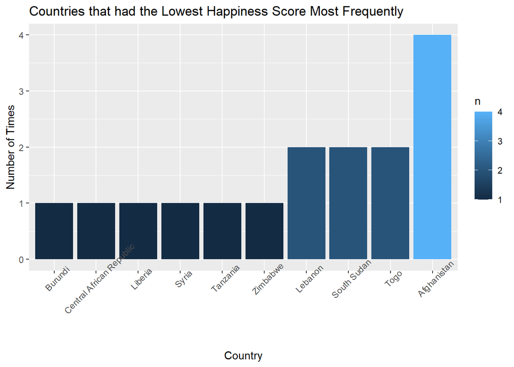

## Why the differences between average and min?

- In comparing the average min happiness plot to the number of times plot there are some differences. This is because some countries, like South Sudan, did not submit a world happiness report for all 16 years. In a closer look at the data, if a country only participates in the world happiness report for 5/16 years, the excluded years do not show up as a missing value. In my opinion, the min and max average plots show a better representation of the dataset. Without figuring out the average scores you are more likely to pick up outliers or extreme values.

# Next, Let’s start exploring some factors(variables) that might influence the happiness score.

- Let’s see if there is a relationship between having confidence in the national government and overall well-being.

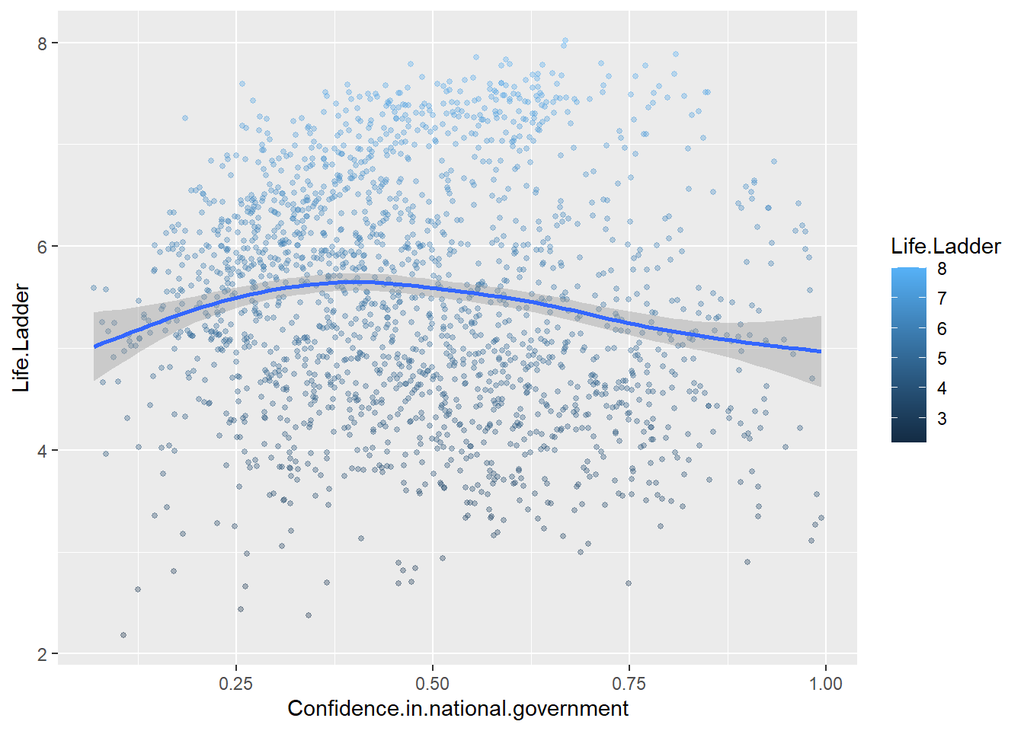

- This chart is overplotted and it is difficult to see a clear relationship.
  - Let’s filter the data to different years to see if a relationship emerges.

```r
#Filter the data to five year intervals
year_data=data1 %>% filter(Year == 2006|Year == 2011|Year == 2016|Year == 2021) %>%
  select(Country.Name,
         Life.Ladder,Confidence.in.national.government,Year)
```

## Here is a facet_wrap plot showing the relationship between confidence in the Govt and happiness score on 5 year intervals

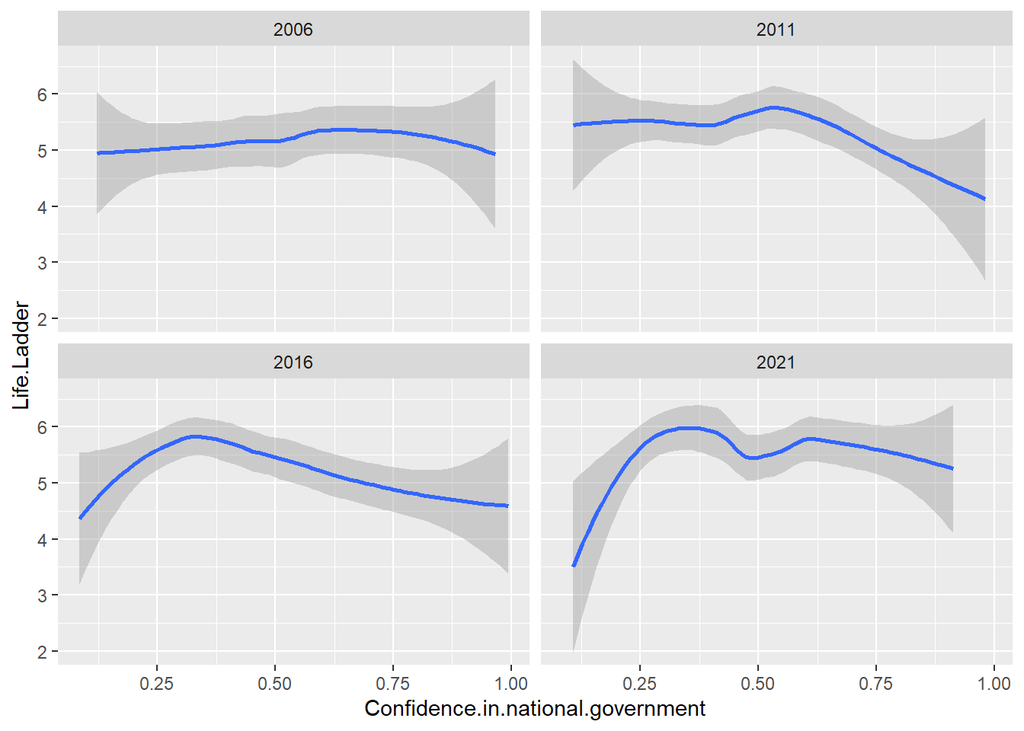

There doesn’t appear to be a clear relationship between confidence in the national government and happiness scores.

- Next up is a different variable: the perception of corruption.

### Is a Perception of corruption related to general well being?:

### Bolivia, USA, and Denmark

Respondents answered the binary question of: “Is corruption widespread within businesses/government or not?”

- I have heard that there is a high perception of corruption in Bolivia. I wanted to explore the relationship with a plot. We will look at the relationship between Denmark, USA, and Bolivia. Each dot in the plot will represent a survey year. The x- axis represents perception of corruption and the y-axis represents Life.Ladder scores.

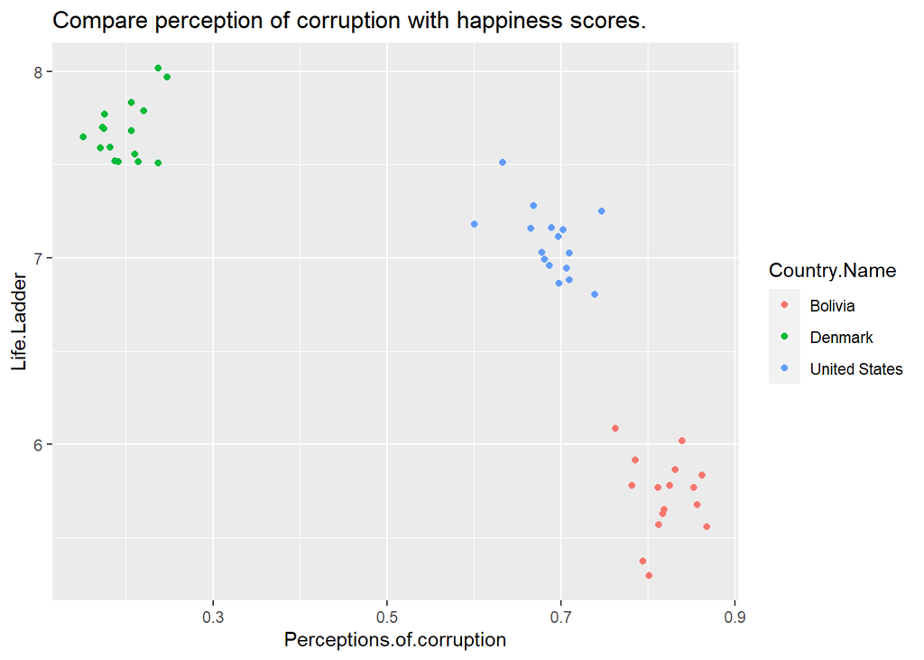

```r
#filter the data to selected countries
US_Bolivia = data1 %>% filter(Country.Name == 'Bolivia'|Country.Name == 'United States'|Country.Name == 'Denmark')

#plot the new filtered data
Bolivia_corruption_plot =
  ggplot(US_Bolivia,aes(Perceptions.of.corruption,
                       Life.Ladder,color=Country.Name))+geom_point()+
ggtitle('Compare perception of corruption with happiness scores.')
Bolivia_corruption_plot
```

- After looking at the plot there seems to be a clear relationship. As perception of corruption increases the happiness scores decrease. This is consistent with the three different countries.
- Next we will look at the variable of life expectancy.

## Does healthy Life Expectancy have a relationship with Well-Being?

- Let’s explore a scatter plot between Kenya, India, Mexico, and Finland.

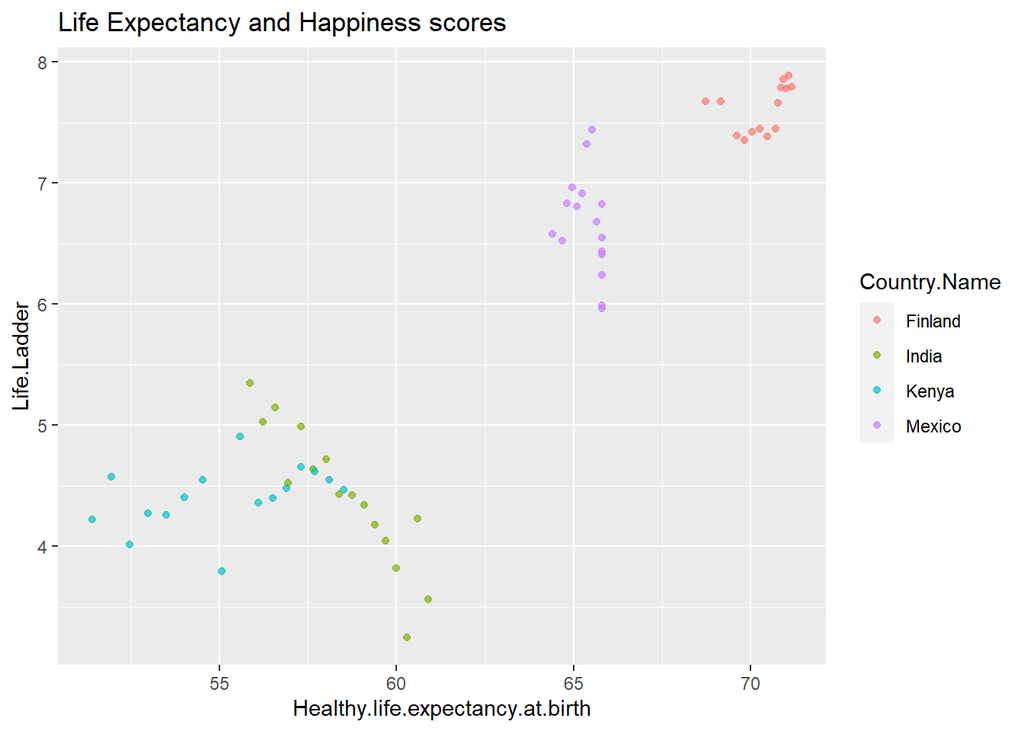

- There appears to be an increasing, positive relationship. As life expectancy increases the Life.Ladder score increases as well.

# Categorize the data by Continent

- Next, let’s use the countrycode library to take a look at happiness in each continent.

```r
##Five Continent Model

#use the countrycode library to categorize by continent
data1$Continent = countrycode(sourcevar = data1$Country.Name,
                             origin = "country.name",
                             destination = "continent")

#The library was unfamiliar with Kosovo but the internet says it's in Europe
data1$Continent[data1$Country.Name == "Kosovo"] = "Europe"

by_continent = data1 %>% select(Country.Name,Continent, Life.Ladder) %>% arrange(Continent) %>% group_by(Continent)
```

- Countrycode uses the five continent model:
- Let’s look at a dataframe showing the Life.Ladder for each continent
  - average
  - max
  - min

```
## # A tibble: 5 × 4
##   Continent   avg   max   min
##   <chr>     <dbl> <dbl> <dbl>
## 1 Africa     4.39  6.35  2.69
## 2 Americas   6.10  7.65  3.35
## 3 Asia       5.29  7.58  2.18
## 4 Europe     6.18  8.02  3.84
## 5 Oceania    7.28  7.60  7.11
```

## Because of the closeness in Oceania’s numbers, let’s take a closer look at Oceania to see which countries it represents in this dataset.

```r
Oceania =data1 %>% filter(Continent == 'Oceania') %>% count(Country.Name)
Oceania
```

```
##   Country.Name  n
## 1    Australia 15
## 2  New Zealand 15
```

- Now we know it only represents two countries. The 15 represents the number of years. I didn’t want to delete an entire continent, however it’s important to remember that Oceania only represents two countries and there is not much variance in their numbers.